# Creating dataset

Xu Liu

# 1 Data structures

- R has a wide variety of objects for holding data, including **scalars, vectors, matrices, arrays, data frames**, and **lists**.

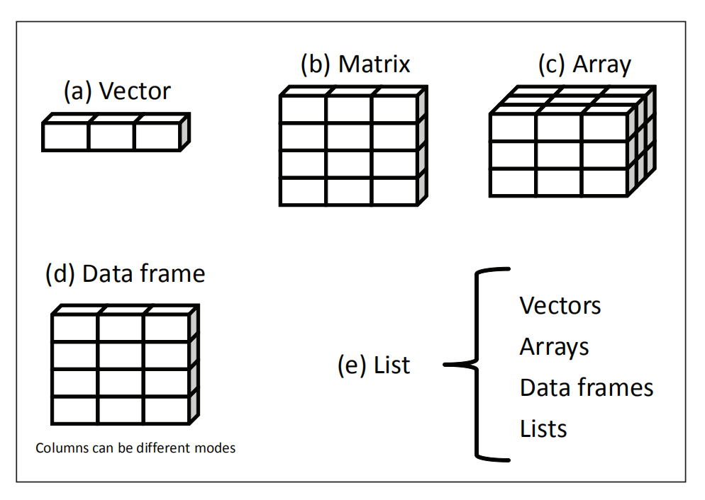

**R data structures**

## 1.1 Vectors

- **Vectors** are one-dimensional arrays that can hold numeric data, character data, or logical data. The combine function **c()** is used to form the vector. Here are examples of each type of vector:

```r
a <- c(1, 2, 5, 3, 6, -2, 4)
a
```

```
## [1]  1  2  5  3  6 -2  4
```

```r
b <- c("one", "two", "three")
b
```

```
## [1] "one"   "two"   "three"
```

```r
c <- c(TRUE, TRUE, TRUE, FALSE, TRUE, FALSE)
c
```

```
## [1]  TRUE  TRUE  TRUE FALSE  TRUE FALSE
```

Here, *a* is numeric vector, *b* is a character vector, and *c* is a logical vector.

```r
e <- c(1, 3, 5)
f <- c(2, 4, 6)
c(e, f)
```

```
## [1] 1 3 5 2 4 6
```

### 1.1.1 Generating regular sequences

- The *colon* operator `:` used in the last statement is used to generate a sequence of numbers. For example

```r
a <- c(1:6)
a
```

```
## [1] 1 2 3 4 5 6
```

or

```r
a <- 1:6
a
```

```
## [1] 1 2 3 4 5 6
```

is equivalent to

```r
a <- c(1, 2, 3, 4, 5, 6)
a
```

```
## [1] 1 2 3 4 5 6
```

```r
a <- 6:1
a
```

```
## [1] 6 5 4 3 2 1
```

- The function `seq()` is a more general facility for generating sequences. For example

```r
seq(-5, 5, by = .2)
```

```
##  [1] -5.0 -4.8 -4.6 -4.4 -4.2 -4.0 -3.8 -3.6 -3.4 -3.2 -3.0 -2.8 -2.6 -2.4
## [15] -2.2 -2.0 -1.8 -1.6 -1.4 -1.2 -1.0 -0.8 -0.6 -0.4 -0.2  0.0  0.2  0.4
## [29]  0.6  0.8  1.0  1.2  1.4  1.6  1.8  2.0  2.2  2.4  2.6  2.8  3.0  3.2
## [43]  3.4  3.6  3.8  4.0  4.2  4.4  4.6  4.8  5.0
```

```r
seq(from = -5, to = 5, length.out = 51)
```

```
##  [1] -5.0 -4.8 -4.6 -4.4 -4.2 -4.0 -3.8 -3.6 -3.4 -3.2 -3.0 -2.8 -2.6 -2.4
## [15] -2.2 -2.0 -1.8 -1.6 -1.4 -1.2 -1.0 -0.8 -0.6 -0.4 -0.2  0.0  0.2  0.4
## [29]  0.6  0.8  1.0  1.2  1.4  1.6  1.8  2.0  2.2  2.4  2.6  2.8  3.0  3.2
## [43]  3.4  3.6  3.8  4.0  4.2  4.4  4.6  4.8  5.0
```

```r
seq.int(-5, 5, by = 2)
```

```
## [1] -5 -3 -1  1  3  5
```

```r
seq(10)
```

```
##  [1]  1  2  3  4  5  6  7  8  9 10
```

or

```r
seq(length.out= 10)
```

```
##  [1]  1  2  3  4  5  6  7  8  9 10
```

is equivalent to

```r
1:10
```

```
##  [1]  1  2  3  4  5  6  7  8  9 10
```

- A related function is `rep()` which can be used for replicating an object in various complicated ways. The simplest form is

```r
 a1 <- rep(x, times = 5)
```

which will put five copies of `x` end-to-end in `a1`. Another useful version is

```r
 a2 <- rep(x, each = 5)
```

which repeats each element of `x` five times before moving on to the next.

- For example

  ```r
  rep(1:3, times = 5)
  ```

  ```
  ##  [1] 1 2 3 1 2 3 1 2 3 1 2 3 1 2 3
  ```

  ```r
  rep(1:3, each = 5)
  ```

  ```
  ##  [1] 1 1 1 1 1 2 2 2 2 2 3 3 3 3 3
  ```

- You can refer to elements of a vector using a numeric vector of positions within brackets.
  - For example, `a[c(2, 4)]` refers to the 2th and 4th element of vector `a`.
  - Here are additional examples:

  ```r
  a <- c(1, 2, 5, 3, 5, -2, 5)
  a[c(2, 4)]
  ```

  ```
  ## [1] 2 3
  ```

  ```r
  a[5]
  ```

  ```
  ## [1] 5
  ```

  ```r
  a[c(1, 3, 5)]
  ```

  ```
  ## [1] 1 5 5
  ```

  ```r
  a[2:6]
  ```

  ```
  ## [1]  2  5  3  5 -2
  ```

  ```r
  a[-1]
  ```

  ```
  ## [1]  2  5  3  5 -2  5
  ```

  ```r
  a[-c(1, 3, 5)]
  ```

  ```
  ## [1]  2  3 -2  5
  ```

  ```r
  which(a==5)
  ```

  ```
  ## [1] 3 5 7
  ```

## 1.2 Matrices

- A matrix is a two-dimensional array where each element has the **same mode** (numeric, character, or logical). Matrices are created with the `matrix` function . The general format is

```r
matrix(vector, nrow = number_of_rows, ncol = number_of_columns,
       byrow = logical_value,
       dimnames = list(char_vector_rownames, char_vector_colnames))
```

where *vector* contains the elements for the matrix, `nrow` and `ncol` specify the row and column dimensions, and `dimnames` contains optional row and column labels stored in character vectors. The option `byrow` indicates whether the matrix should be filled in by row (`byrow=TRUE`) or by column (`byrow=FALSE`). The default is by column. The following listing demonstrates the `matrix` function .

```r
 y <- matrix(1:20, nrow=5, ncol=4)
 y
```

```
##      [,1] [,2] [,3] [,4]
## [1,]    1    6   11   16
## [2,]    2    7   12   17
## [3,]    3    8   13   18
## [4,]    4    9   14   19
## [5,]    5   10   15   20
```

```r
 cells <- c(1,26,24,68)
 rnames <- c("R1", "R2")
 cnames <- c("C1", "C2")
 matrix(cells, nrow=2, ncol=2, byrow=TRUE, dimnames=list(rnames, cnames))
```

```
##    C1 C2
## R1  1 26
## R2 24 68
```

```r
 matrix(cells, nrow=2, ncol=2, byrow=FALSE, dimnames=list(rnames, cnames))
```

```
##    C1 C2
## R1  1 24
## R2 26 68
```

- Another way to create a matrix is to give the appropriate values to the `dim` attribute. For examples

```r
x <- 1:15
dim(x)
```

[output not shown]

```r
dim(x) <- c(5, 3)
x
```

```
##      [,1] [,2] [,3]
## [1,]    1    6   11
## [2,]    2    7   12
## [3,]    3    8   13
## [4,]    4    9   14
## [5,]    5   10   15
```

```r
x <- matrix(1:15,5,3)
x
```

```
##      [,1] [,2] [,3]
## [1,]    1    6   11
## [2,]    2    7   12
## [3,]    3    8   13
## [4,]    4    9   14
## [5,]    5   10   15
```

```r
dim(x) <- c(3, 5)
x
```

```
##      [,1] [,2] [,3] [,4] [,5]
## [1,]    1    4    7   10   13
## [2,]    2    5    8   11   14
## [3,]    3    6    9   12   15
```

- Random matrix

```r
matrix(rnorm(24),6,4)
```

```
##            [,1]       [,2]       [,3]        [,4]
## [1,] -0.3664375 -0.7235620 -0.9946803 -0.42207274
## [2,] -0.5245551 -0.7020465 -0.4334180  0.58249191
## [3,]  1.1483079 -0.1668533  0.5150201  1.21226226
## [4,]  0.5015884 -0.7824970  0.6348669 -0.08830277
## [5,] -0.6773089  0.9450054  0.1937233  0.01231141
## [6,]  0.1598761  0.5679469 -0.1299620 -1.24939112
```

- Some special matrix

```r
x <- 1:6
diag(x)
```

```
##      [,1] [,2] [,3] [,4] [,5] [,6]
## [1,]    1    0    0    0    0    0
## [2,]    0    2    0    0    0    0
## [3,]    0    0    3    0    0    0
## [4,]    0    0    0    4    0    0
## [5,]    0    0    0    0    5    0
## [6,]    0    0    0    0    0    6
```

```r
x <- rep(1,6)
diag(x)
```

```
##      [,1] [,2] [,3] [,4] [,5] [,6]
## [1,]    1    0    0    0    0    0
## [2,]    0    1    0    0    0    0
## [3,]    0    0    1    0    0    0
## [4,]    0    0    0    1    0    0
## [5,]    0    0    0    0    1    0
## [6,]    0    0    0    0    0    1
```

or

```r
x <- 1
diag(x, nrow=6)
```

```
##      [,1] [,2] [,3] [,4] [,5] [,6]
## [1,]    1    0    0    0    0    0
## [2,]    0    1    0    0    0    0
## [3,]    0    0    1    0    0    0
## [4,]    0    0    0    1    0    0
## [5,]    0    0    0    0    1    0
## [6,]    0    0    0    0    0    1
```

```r
x <- matrix(1:36,6,6)
x
```

```
##      [,1] [,2] [,3] [,4] [,5] [,6]
## [1,]    1    7   13   19   25   31
## [2,]    2    8   14   20   26   32
## [3,]    3    9   15   21   27   33
## [4,]    4   10   16   22   28   34
## [5,]    5   11   17   23   29   35
## [6,]    6   12   18   24   30   36
```

```r
diag(x)
```

```
## [1]  1  8 15 22 29 36
```

```r
matrix(rep(0,20),4,5)
```

```
##      [,1] [,2] [,3] [,4] [,5]
## [1,]    0    0    0    0    0
## [2,]    0    0    0    0    0
## [3,]    0    0    0    0    0
## [4,]    0    0    0    0    0
```

or

```r
matrix(0,4,5)
```

```
##      [,1] [,2] [,3] [,4] [,5]
## [1,]    0    0    0    0    0
## [2,]    0    0    0    0    0
## [3,]    0    0    0    0    0
## [4,]    0    0    0    0    0
```

```r
matrix(1,4,5)
```

```
##      [,1] [,2] [,3] [,4] [,5]
## [1,]    1    1    1    1    1
## [2,]    1    1    1    1    1
## [3,]    1    1    1    1    1
## [4,]    1    1    1    1    1
```

- Identify rows, columns, or elements of a matrix by using subscripts and brackets. `X[i,]` refers to the `i`th row of matrix `X`, `X[,j]` refers to jth column, and `X[i, j]` refers to the `ij`th element, respectively. The subscripts `i` and `j` can be numeric vectors in order to select multiple rows or columns, as shown in the following listing.

```r
 x <- matrix(1:10, nrow=2)
 x
```

```
##      [,1] [,2] [,3] [,4] [,5]
## [1,]    1    3    5    7    9
## [2,]    2    4    6    8   10
```

```r
 x[2,]
```

```
## [1]  2  4  6  8 10
```

```r
 x[,2]
```

```
## [1] 3 4
```

```r
 x[1,4]
```

```
## [1] 7
```

```r
 x[1, c(4,5)]
```

```
## [1] 7 9
```

```r
x <- matrix(1:20, nrow=5)
x
```

```
##      [,1] [,2] [,3] [,4]
## [1,]    1    6   11   16
## [2,]    2    7   12   17
## [3,]    3    8   13   18
## [4,]    4    9   14   19
## [5,]    5   10   15   20
```

```r
x[-c(1, 5), ]
```

```
##      [,1] [,2] [,3] [,4]
## [1,]    2    7   12   17
## [2,]    3    8   13   18
## [3,]    4    9   14   19
```

```r
x[-1,]
```

```
##      [,1] [,2] [,3] [,4]
## [1,]    2    7   12   17
## [2,]    3    8   13   18
## [3,]    4    9   14   19
## [4,]    5   10   15   20
```

```r
x[,-1]
```

```
##      [,1] [,2] [,3]
## [1,]    6   11   16
## [2,]    7   12   17
## [3,]    8   13   18
## [4,]    9   14   19
## [5,]   10   15   20
```

```r
x[,-c(1, 3)]
```

```
##      [,1] [,2]
## [1,]    6   16
## [2,]    7   17
## [3,]    8   18
## [4,]    9   19
## [5,]   10   20
```

## 1.3 Arrays

- Arrays are similar to matrices but can have more than two dimensions. They’re created with an array function of the following form:

```r
array(vector, dimensions, dimnames)
```

where *vector* contains the data for the array, *dimensions* is a numeric vector giving the maximal index for each dimension, and *dimnames* is an optional list of dimension labels. For example

```r
array(1:24, dim = c(3, 4, 2))
```

```
## , , 1
##
##      [,1] [,2] [,3] [,4]
## [1,]    1    4    7   10
## [2,]    2    5    8   11
## [3,]    3    6    9   12
##
## , , 2
##
##      [,1] [,2] [,3] [,4]
## [1,]   13   16   19   22
## [2,]   14   17   20   23
## [3,]   15   18   21   24
```

```r
dim1 <- c("A1", "A2")
dim2 <- c("B1", "B2", "B3")
dim3 <- c("C1", "C2", "C3", "C4")
z <- array(1:24, c(2, 3, 4), dimnames=list(dim1, dim2, dim3))
z
```

```
## , , C1
##
##    B1 B2 B3
## A1  1  3  5
## A2  2  4  6
##
## , , C2
##
##    B1 B2 B3
## A1  7  9 11
## A2  8 10 12
##
## , , C3
##
##    B1 B2 B3
## A1 13 15 17
## A2 14 16 18
##
## , , C4
##
##    B1 B2 B3
## A1 19 21 23
## A2 20 22 24
```

```r
z[,,1];z[,,2];z[,,3];z[,,4]
```

```
##    B1 B2 B3
## A1  1  3  5
## A2  2  4  6
```

```
##    B1 B2 B3
## A1  7  9 11
## A2  8 10 12
```

```
##    B1 B2 B3
## A1 13 15 17
## A2 14 16 18
```

```
##    B1 B2 B3
## A1 19 21 23
## A2 20 22 24
```

```r
z[1,,]
```

```
##    C1 C2 C3 C4
## B1  1  7 13 19
## B2  3  9 15 21
## B3  5 11 17 23
```

```r
z[,2,]
```

```
##    C1 C2 C3 C4
## A1  3  9 15 21
## A2  4 10 16 22
```

```r
z[1,2,3]
```

```
## [1] 15
```

## 1.4 Data frames

- A data frame is more general than a matrix in that different columns can contain **different modes of data** (numeric, character, etc.). It’s similar to the datasets you’d typically see in SAS, SPSS, and Stata. Data frames are the most common data structure you’ll deal with in R. A data frame is created with the `data.frame()` function:

```r
mydata <- data.frame(col1, col2, col3,...)
```

where *col1*, *col2*, *col3*, … are column vectors of any type (such as character, numeric, or logical). Names for each column can be provided with the names function. The following listing makes this clear.

```r
 patientID <- c(1, 2, 3, 4)
 age <- c(25, 34, 28, 52)
 diabetes <- c("Type1", "Type2", "Type1", "Type1")
 status <- c("Poor", "Improved", "Excellent", "Poor")
 patientdata <- data.frame(patientID, age, diabetes, status)
 patientdata
```

| patientID | age | diabetes | status |
| --- | --- | --- | --- |
| 1 | 25 | Type1 | Poor |
| 2 | 34 | Type2 | Improved |
| 3 | 28 | Type1 | Excellent |
| 4 | 52 | Type1 | Poor |

**NOTE:** Each column must have only one mode, but you can put columns of different modes together to form the data frame.

### 1.4.1 Specifying elements of a data frame

- There are several ways to identify the elements of a data frame. You can use the subscript notation you used before (for example, with matrices) or you can specify column names. The following listing demonstrates these approaches.

```r
 patientdata[1:2,]
```

| patientID | age | diabetes | status |
| --- | --- | --- | --- |
| 1 | 25 | Type1 | Poor |
| 2 | 34 | Type2 | Improved |

```r
 patientdata[,1:2]
```

| patientID | age |
| --- | --- |
| 1 | 25 |
| 2 | 34 |
| 3 | 28 |
| 4 | 52 |

```r
 patientdata[,-1]
```

| age | diabetes | status |
| --- | --- | --- |
| 25 | Type1 | Poor |
| 34 | Type2 | Improved |
| 28 | Type1 | Excellent |
| 52 | Type1 | Poor |

```r
 patientdata[,c("diabetes", "status")]
```

| diabetes | status |
| --- | --- |
| Type1 | Poor |
| Type2 | Improved |
| Type1 | Excellent |
| Type1 | Poor |

```r
patientdata[,"age"]
```

```
## [1] 25 34 28 52
```

```r
patientdata$age
```

```
## [1] 25 34 28 52
```

The `$` is used to indicate a particular variable from a given data frame.

## 1.5 Factors

- **Variables** can be described as *nominal*, *ordinal*, or *continuous*.
  - *Nominal* variables are *categorical*, without an implied order. `Diabetes (Type1, Type2)` is an example of a nominal variable.
  - *Ordinal* variables imply order but not amount. `Status (poor, improved, excellent)` is a good example of an ordinal variable.
  - *Continuous* variables can take on any value within some range, and both order and amount are implied. For example, *Age* in years is a continuous variable.
- *Categorical* (*nominal*) and *ordered categorical* (*ordinal*) variables in R are called factors.
- The function `factor()` stores the categorical values as a vector of integers in the range `[1... k]` (where `k` is the number of unique values in the nominal variable), and an internal vector of character strings (the original values) mapped to these integers.

For example, assume that you have the vector

```r
diabetes <- c("Type1", "Type2", "Type1", "Type1")
diabetes <- factor(diabetes)
diabetes
```

```
## [1] Type1 Type2 Type1 Type1
## Levels: Type1 Type2
```

The statement `diabetes <- factor(diabetes)` stores this vector as `(1, 2, 1, 1)` and associates it with *1=Type1* and *2=Type2* internally (the assignment is alphabetical). Any analyses performed on the vector diabetes will treat the variable as nominal and select the statistical methods appropriate for this level of measurement.

- For vectors representing ordinal variables, the parameter `ordered=TRUE` is required in the function `factor()`. For example

```r
status <- c("Poor", "Improved", "Excellent", "Poor")
status <- factor(status, ordered=TRUE)
status
```

```
## [1] Poor      Improved  Excellent Poor
## Levels: Excellent < Improved < Poor
```

the statement `status <- factor(status, ordered=TRUE)` will encode the vector as `(3, 2, 1, 3)` and associate these values internally as *1=Excellent*, *2=Improved*, and *3=Poor*. Additionally, any analyses performed on this vector will treat the variable as ordinal and select the statistical methods appropriately.

- The following listing demonstrates how specifying factors and ordered factors impact data analyses.

```r
 patientID <- c(1, 2, 3, 4)
 age <- c(25, 34, 28, 52)
 diabetes <- c("Type1", "Type2", "Type1", "Type1")
 status <- c("Poor", "Improved", "Excellent", "Poor")
 diabetes <- factor(diabetes)
 status <- factor(status, order=TRUE)
 patientdata <- data.frame(patientID, age, diabetes, status)
 patientdata
```

| patientID | age | diabetes | status |
| --- | --- | --- | --- |
| 1 | 25 | Type1 | Poor |
| 2 | 34 | Type2 | Improved |
| 3 | 28 | Type1 | Excellent |
| 4 | 52 | Type1 | Poor |

```r
 str(patientdata)
```

```
## 'data.frame':    4 obs. of  4 variables:
##  $ patientID: num  1 2 3 4
##  $ age      : num  25 34 28 52
##  $ diabetes : Factor w/ 2 levels "Type1","Type2": 1 2 1 1
##  $ status   : Ord.factor w/ 3 levels "Excellent"<"Improved"<..: 3 2 1 3
```

```r
 summary(patientdata)
```

```
##    patientID         age         diabetes       status
##  Min.   :1.00   Min.   :25.00   Type1:3   Excellent:1
##  1st Qu.:1.75   1st Qu.:27.25   Type2:1   Improved :1
##  Median :2.50   Median :31.00             Poor     :2
##  Mean   :2.50   Mean   :34.75
##  3rd Qu.:3.25   3rd Qu.:38.50
##  Max.   :4.00   Max.   :52.00
```

**NOTE:** The function `str(object)` provides information on an object in R. The `summary()` function treats the variables differently. It provides the *minimum*, *maximum*, *mean*, and *quartiles* for the continuous variable *age*, and *frequency* counts for the *categorical* variables *diabetes* and *status*.

## 1.6 Lists

- A list is an ordered collection of objects (components). A list allows you to gather a variety of (possibly unrelated) objects under one name. For example, a list may contain a combination of vectors, matrices, data frames, and even other lists. You create a list using the `list()` function:

```r
mylist <- list(object1, object2, ...)
```

where the *objects* are any of the structures seen so far. Optionally, you can name the *objects* in a list:

```r
mylist <- list(name1=object1, name2=object2,...)
```

The following listing shows an example.

```r
 g <- "My First List"
 h <- c(25, 26, 18, 39)
 j <- matrix(1:10, nrow=5)
 k <- c("one", "two", "three")
 mylist <- list(title=g, ages=h, j, k)
 mylist
```

```
## $title
## [1] "My First List"
##
## $ages
## [1] 25 26 18 39
##
## [[3]]
##      [,1] [,2]
## [1,]    1    6
## [2,]    2    7
## [3,]    3    8
## [4,]    4    9
## [5,]    5   10
##
## [[4]]
## [1] "one"   "two"   "three"
```

- Elements of a list can be accessed by indicating a component number or a name within double brackets. For example:

```r
mylist[[1]]
```

```
## [1] "My First List"
```

```r
mylist[['title']]
```

```
## [1] "My First List"
```

```r
mylist$title
```

```
## [1] "My First List"
```

```r
mylist[[2]]
```

```
## [1] 25 26 18 39
```

```r
mylist[['ages']]
```

```
## [1] 25 26 18 39
```

```r
mylist$ages
```

```
## [1] 25 26 18 39
```

```r
mylist[[3]]
```

```
##      [,1] [,2]
## [1,]    1    6
## [2,]    2    7
## [3,]    3    8
## [4,]    4    9
## [5,]    5   10
```

```r
mylist[[4]]
```

```
## [1] "one"   "two"   "three"
```

# 2 Data input

- As a data analyst, we face typically the data that comes to us from a variety of sources and in a variety of formats. The task is to import the data into our tools, analyze the data, and report on the results. R provides a wide range of tools for importing data. The definitive guide for importing data in R is the R Data *Import/Export* manual available at http://cran.r-project.org/doc/manuals/R-data.pdf.

## 2.1 Entering data from the keyboard

- Perhaps the simplest method of data entry is from the keyboard. For example:

```r
mymatrix=matrix(c(1,3,5,7,9,11,13,15,17),3,3)
mymatrix
```

```
##      [,1] [,2] [,3]
## [1,]    1    7   13
## [2,]    3    9   15
## [3,]    5   11   17
```

```r
 patientID <- c(1, 2, 3, 4)
 age <- c(25, 34, 28, 52)
 diabetes <- c("Type1", "Type2", "Type1", "Type1")
 status <- c("Poor", "Improved", "Excellent", "Poor")
 patientdata <- data.frame(patientID, age, diabetes, status)
 patientdata
```

| patientID | age | diabetes | status |
| --- | --- | --- | --- |
| 1 | 25 | Type1 | Poor |
| 2 | 34 | Type2 | Improved |
| 3 | 28 | Type1 | Excellent |
| 4 | 52 | Type1 | Poor |

## 2.2 Importing data from delimited text files

- The delimited text files can be imported by using `read.table()` , a function that reads a file in table format and saves it as a data frame. Here’s the syntax:

```r
mydataframe <- read.table(file, header=logical_value, sep="delimiter"...)
```

where *file* is a delimited ASCII file , *header* is a logical value indicating whether the first row contains variable names (TRUE or FALSE). *sep* specifies the delimiter separating data values. For example

```r
grades <- read.table("studentgrades.txt", header=TRUE, sep=",")
grades
```

| StudentID | First | Last | Math | Science | Social.Studies |
| --- | --- | --- | --- | --- | --- |
| 11 | Bob | Smith | 90 | 80 | 67 |
| 12 | Jane | Weary | 75 | NA | 80 |
| 10 | Dan | Thornton | 65 | 75 | 70 |
| 40 | Mary | O’Leary | 90 | 95 | 92 |

- The variants of `read.table` are useful, for example, `read.csv`.

```r
grades <- read.csv("studentgrades.csv", header=TRUE)##Usefull
grades
```

| StudentID | First | Last | Math | Science | Social.Studies |
| --- | --- | --- | --- | --- | --- |
| 11 | Bob | Smith | 90 | 80 | 67 |
| 12 | Jane | Weary | 75 | NA | 80 |
| 10 | Dan | Thornton | 65 | 75 | 70 |
| 40 | Mary | O’Leary | 90 | 95 | 92 |

## 2.3 Importing data from Excel

- Excel 2007 uses an *XLSX* file format, which is essentially a zipped set of XML files. The *XLSX* package can be used to access spreadsheets in this format. Be sure to download and install it before first use. The `read.xlsx()` function imports a worksheet from an *XLSX* file into a data frame. The simplest format is `read.xlsx(file, n)` where *file* is the path to an Excel 2007 workbook and *n* is the number of the worksheet to be imported. For example,

  ```r
  #install.packages('xlsx')
  library(xlsx)
  mydataframe <- read.xlsx("studentgrades.xlsx", 1)
  mydataframe
  ```

  | StudentID | First | Last | Math | Science | Social.Studies | NA. |
  | --- | --- | --- | --- | --- | --- | --- |
  | 11 | Bob | Smith | 90 | 80 | 67 | NA |
  | 12 | Jane | Weary | 75 | NA | 80 | NA |
  | 10 | Dan | Thornton | 65 | 75 | 70 | NA |
  | 40 | Mary | O’Leary | 90 | 95 | 92 | NA |

- Or get the detailed usage from [xlsx index](https://cran.r-project.org/web/packages/xlsx/index.html)
- Install following packages sequentially

  ````
  ```r
  install.packages("rJava")
  install.packages("xlsxjars")
  install.packages("xlsx")
  library(rJava)
  library(xlsxjars)
  library(xlsx)
  ```
  ````

  - If there are still errors about *Java*, you may need to download [*Java*](https://www.oracle.com/technetwork/java/javase/downloads/jdk8-downloads-2133151.html), and install *Java* into your local fold “*C:\Program Files*”, which is defalt.
  - Remember to setup *environment variables*. On **cmd** command line, type

    ```r
    set JAVA_HOME=C:\Program Files\Java\jdk1.8.0_171 Path=C:\Program Files\Java\jdk1.8.0_211\bin
    ```

  - Or setup *environment variables* manually by adding **path** *C:\Program Files\Java\jdk1.8.0_211\bin*

## 2.4 Importing data from MySQL

### 2.4.2 Getting RODBC working

- Before using **RODBC**, it is required to configure the **ODBC** connection. After configuring R to communicate with your database, it is ready to use **RODBC**.
  1. Install **MySQL** and **ODBC** connector to your database, if you donot have. The details can be found [here](http://rpubs.com/xliusufe/Rmysqr).
  2. Install the **RODBC** package in R. Get the detailed usage from [RODBC index](https://cran.r-project.org/web/packages/RODBC/index.html)
  3. Configure the **ODBC** connection to your database.
- Installing the R package **RODBC**. A quick way to install the **RODBC** package is to use the function `install.packages`:

```r
 install.packages("RODBC")
 library(RODBC)
 help(package="RODBC")
```

- Using **RODBC**. Connecting to a database in R is similor to connecting to a file.
  - connect to a database with function `odbcConnect()`.
  - execute any database queries.
  - close the connection with function `close()`.
- Establishing a connection by using the function `odbcConnect()`:

```r
odbcConnect(dsn, uid = "", pwd = "", ...)
```

For example:

```r
library(RODBC)
con<-odbcConnect('mydata',uid="root",pwd='lx5609')
sqlTables(con) # List the table-like objects accessible from an ODBC connection.
```

| TABLE_CAT | TABLE_SCHEM | TABLE_NAME | TABLE_TYPE | REMARKS |
| --- | --- | --- | --- | --- |
| mysql |  | bmw_stock | TABLE |  |
| mysql |  | columns_priv | TABLE | Column privileges |
| mysql |  | db | TABLE | Database privileges |
| mysql |  | engine_cost | TABLE |  |
| mysql |  | event | TABLE | Events |
| mysql |  | func | TABLE | User defined functions |
| mysql |  | general_log | TABLE | General log |
| mysql |  | gtid_executed | TABLE |  |
| mysql |  | help_category | TABLE | help categories |
| mysql |  | help_keyword | TABLE | help keywords |
| mysql |  | help_relation | TABLE | keyword-topic relation |
| mysql |  | help_topic | TABLE | help topics |
| mysql |  | innodb_index_stats | TABLE |  |
| mysql |  | innodb_table_stats | TABLE |  |
| mysql |  | ndb_binlog_index | TABLE |  |
| mysql |  | patient | TABLE |  |
| mysql |  | patientdata | TABLE |  |
| mysql |  | plugin | TABLE | MySQL plugins |
| mysql |  | proc | TABLE | Stored Procedures |
| mysql |  | procs_priv | TABLE | Procedure privileges |
| mysql |  | proxies_priv | TABLE | User proxy privileges |
| mysql |  | server_cost | TABLE |  |
| mysql |  | servers | TABLE | MySQL Foreign Servers table |
| mysql |  | slave_master_info | TABLE | Master Information |
| mysql |  | slave_relay_log_info | TABLE | Relay Log Information |
| mysql |  | slave_worker_info | TABLE | Worker Information |
| mysql |  | slow_log | TABLE | Slow log |
| mysql |  | tables_priv | TABLE | Table privileges |
| mysql |  | time_zone | TABLE | Time zones |
| mysql |  | time_zone_leap_second | TABLE | Leap seconds information for time zones |
| mysql |  | time_zone_name | TABLE | Time zone names |
| mysql |  | time_zone_transition | TABLE | Time zone transitions |
| mysql |  | time_zone_transition_type | TABLE | Time zone transition types |
| mysql |  | usarrests | TABLE |  |
| mysql |  | user | TABLE | Users and global privileges |

```r
odbcGetInfo(con)  #Request information on an ODBC connection.
```

```
##              DBMS_Name               DBMS_Ver        Driver_ODBC_Ver
##                "MySQL"               "5.7.26"                "03.51"
##       Data_Source_Name            Driver_Name             Driver_Ver
##               "mydata"         "myodbc5a.dll"           "05.02.0007"
##               ODBC_Ver            Server_Name
##           "03.80.0000" "127.0.0.1 via TCP/IP"
```

- Write or update a table in an ODBC database by using the function `sqlSave`. For example, write the data in R into MySQL.

```r
 data(USArrests)
 head(USArrests)
```

|  | Murder | Assault | UrbanPop | Rape |
| --- | --- | --- | --- | --- |
| Alabama | 13.2 | 236 | 58 | 21.2 |
| Alaska | 10.0 | 263 | 48 | 44.5 |
| Arizona | 8.1 | 294 | 80 | 31.0 |
| Arkansas | 8.8 | 190 | 50 | 19.5 |
| California | 9.0 | 276 | 91 | 40.6 |
| Colorado | 7.9 | 204 | 78 | 38.7 |

```r
 sqlDrop(con,"USArrests") # Delete the USArrests data from MySQL.
 sqlSave(con,USArrests, rownames = "state", addPK = TRUE)
 rm(USArrests)
```

- Fetch a table (or view) from the underlying database by using the function `sqlFetch()`. For example:

```r
 result = sqlFetch( con,'USArrests' )
 head(result)
```

| state | murder | assault | urbanpop | rape |
| --- | --- | --- | --- | --- |
| Alabama | 13.2 | 236 | 58 | 21.2 |
| Alaska | 10.0 | 263 | 48 | 44.5 |
| Arizona | 8.1 | 294 | 80 | 31.0 |
| Arkansas | 8.8 | 190 | 50 | 19.5 |
| California | 9.0 | 276 | 91 | 40.6 |
| Colorado | 7.9 | 204 | 78 | 38.7 |

```r
 close( con )
```

### 2.4.3 Using R package **RMySQL**

- R package **RMySQL** is powerful to read, write and delete data.

```r
help(package="RMySQL")
```

- Or get the detailed usage from [RMySQL index](https://cran.r-project.org/web/packages/RMySQL/index.html)
- Use the function `dbConnect` to establish a connection. For example

```r
 #install.packages("RMySQL")
 library(RMySQL)
 #con <- dbConnect(RMySQL::MySQL(), dbname = "mydata", username="root", password="lx5609",
 #        host="127.0.0.1", port=3306)
 con <- dbConnect(MySQL(), dbname = "mysql", username="root", password="lx5609")
 dbGetInfo(con)
```

```
## $host
## [1] "localhost"
##
## $user
## [1] "root"
##
## $dbname
## [1] "mysql"
##
## $conType
## [1] "localhost via TCP/IP"
##
## $serverVersion
## [1] "5.7.26"
##
## $protocolVersion
## [1] 10
##
## $threadId
## [1] 200
##
## $rsId
## list()
```

```r
 dbListTables(con)
```

```
##  [1] "bmw_stock"                 "columns_priv"
##  [3] "db"                        "engine_cost"
##  [5] "event"                     "func"
##  [7] "general_log"               "gtid_executed"
##  [9] "help_category"             "help_keyword"
## [11] "help_relation"             "help_topic"
## [13] "innodb_index_stats"        "innodb_table_stats"
## [15] "ndb_binlog_index"          "patient"
## [17] "patientdata"               "plugin"
## [19] "proc"                      "procs_priv"
## [21] "proxies_priv"              "server_cost"
## [23] "servers"                   "slave_master_info"
## [25] "slave_relay_log_info"      "slave_worker_info"
## [27] "slow_log"                  "tables_priv"
## [29] "time_zone"                 "time_zone_leap_second"
## [31] "time_zone_name"            "time_zone_transition"
## [33] "time_zone_transition_type" "usarrests"
## [35] "user"
```

- Use the function `dbWriteTable` to write or update a table. For example, write the *BMW stock* data into MySQL.
  - Download and save data

```r
 #install.packages('quantmod')
 library(quantmod)
 bmw_stock = new.env()
 getSymbols('BMW.DE', env = bmw_stock, src = 'yahoo',
            from = as.Date("2016-01-01"), to = as.Date("2018-12-31"))
 BMW = bmw_stock$BMW.DE
 write.csv(BMW,'BMW_stock.csv',row.names = index(BMW))
```

- Weite the *BMW_stock.csv* data into MySQL.

```r
  BMW_STOCK <- read.csv("BMW_stock.csv", head = T)
  head(BMW_STOCK)
```

| Date | BMW.DE.Open | BMW.DE.High | BMW.DE.Low | BMW.DE.Close | BMW.DE.Volume | BMW.DE.Adjusted |
| --- | --- | --- | --- | --- | --- | --- |
| 2016/1/4 | 94.71 | 94.71 | 91.76 | 92.25 | 2376296 | 77.20447 |
| 2016/1/5 | 93.42 | 93.50 | 90.63 | 91.82 | 1533191 | 76.84460 |
| 2016/1/6 | 91.00 | 91.00 | 87.14 | 88.78 | 2301978 | 74.30040 |
| 2016/1/7 | 85.30 | 86.00 | 83.52 | 85.44 | 2812427 | 71.50513 |
| 2016/1/8 | 86.16 | 87.14 | 83.41 | 83.44 | 1969156 | 69.83134 |
| 2016/1/11 | 83.11 | 85.59 | 82.88 | 83.14 | 1832479 | 69.58026 |

```r
  dbRemoveTable(con, "bmw_stock")#Delete the data from MySQL.
```

```
## [1] TRUE
```

```r
  dbWriteTable(con,"BMW_STOCK",BMW_STOCK)
```

```
## [1] TRUE
```

```r
  dbListTables(con)
```

```
##  [1] "bmw_stock"                 "columns_priv"
##  [3] "db"                        "engine_cost"
##  [5] "event"                     "func"
##  [7] "general_log"               "gtid_executed"
##  [9] "help_category"             "help_keyword"
## [11] "help_relation"             "help_topic"
## [13] "innodb_index_stats"        "innodb_table_stats"
## [15] "ndb_binlog_index"          "patient"
## [17] "patientdata"               "plugin"
## [19] "proc"                      "procs_priv"
## [21] "proxies_priv"              "server_cost"
## [23] "servers"                   "slave_master_info"
## [25] "slave_relay_log_info"      "slave_worker_info"
## [27] "slow_log"                  "tables_priv"
## [29] "time_zone"                 "time_zone_leap_second"
## [31] "time_zone_name"            "time_zone_transition"
## [33] "time_zone_transition_type" "usarrests"
## [35] "user"
```

- If there is something wrong, please see this [website](https://stackoverflow.com/questions/50745431/trying-to-use-r-with-mysql-the-used-command-is-not-allowed-with-this-mysql-vers).
- Weite the *BMW_stock.xlsx* data into MySQL.

```r
  BMW_STOCK <- read.xlsx("BMW_stock.xlsx", sheetIndex = 1,  head = T,colIndex = 1:7)
  head(BMW_STOCK)
```

| Date | BMW.DE.Open | BMW.DE.High | BMW.DE.Low | BMW.DE.Close | BMW.DE.Volume | BMW.DE.Adjusted |
| --- | --- | --- | --- | --- | --- | --- |
| 2016-01-04 | 94.71 | 94.71 | 91.76 | 92.25 | 2376296 | 77.20447 |
| 2016-01-05 | 93.42 | 93.50 | 90.63 | 91.82 | 1533191 | 76.84460 |
| 2016-01-06 | 91.00 | 91.00 | 87.14 | 88.78 | 2301978 | 74.30040 |
| 2016-01-07 | 85.30 | 86.00 | 83.52 | 85.44 | 2812427 | 71.50513 |
| 2016-01-08 | 86.16 | 87.14 | 83.41 | 83.44 | 1969156 | 69.83134 |
| 2016-01-11 | 83.11 | 85.59 | 82.88 | 83.14 | 1832479 | 69.58026 |

```r
  dbRemoveTable(con, "bmw_stock")#Delete the data from MySQL.
```

```
## [1] TRUE
```

```r
  dbWriteTable(con,"BMW_STOCK",BMW_STOCK)
```

```
## [1] TRUE
```

```r
  dbListTables(con)
```

```
##  [1] "bmw_stock"                 "columns_priv"
##  [3] "db"                        "engine_cost"
##  [5] "event"                     "func"
##  [7] "general_log"               "gtid_executed"
##  [9] "help_category"             "help_keyword"
## [11] "help_relation"             "help_topic"
## [13] "innodb_index_stats"        "innodb_table_stats"
## [15] "ndb_binlog_index"          "patient"
## [17] "patientdata"               "plugin"
## [19] "proc"                      "procs_priv"
## [21] "proxies_priv"              "server_cost"
## [23] "servers"                   "slave_master_info"
## [25] "slave_relay_log_info"      "slave_worker_info"
## [27] "slow_log"                  "tables_priv"
## [29] "time_zone"                 "time_zone_leap_second"
## [31] "time_zone_name"            "time_zone_transition"
## [33] "time_zone_transition_type" "usarrests"
## [35] "user"
```

- Fetch a table (or view) from the underlying database by using the `dbReadTable` function. For example:

```r
 result = dbReadTable(con,"BMW_STOCK")
 head(result)
```

| Date | BMW.DE.Open | BMW.DE.High | BMW.DE.Low | BMW.DE.Close | BMW.DE.Volume | BMW.DE.Adjusted |
| --- | --- | --- | --- | --- | --- | --- |
| 2016-01-04 | 94.71 | 94.71 | 91.76 | 92.25 | 2376296 | 77.20447 |
| 2016-01-05 | 93.42 | 93.50 | 90.63 | 91.82 | 1533191 | 76.84460 |
| 2016-01-06 | 91.00 | 91.00 | 87.14 | 88.78 | 2301978 | 74.30040 |
| 2016-01-07 | 85.30 | 86.00 | 83.52 | 85.44 | 2812427 | 71.50513 |
| 2016-01-08 | 86.16 | 87.14 | 83.41 | 83.44 | 1969156 | 69.83134 |
| 2016-01-11 | 83.11 | 85.59 | 82.88 | 83.14 | 1832479 | 69.58026 |

- Remember to disconnect `con`

  ```r
  dbDisconnect(con)
  ```

  ```
  ## [1] TRUE
  ```

## 2.5 Accessing builtin datasets

- Around 100 datasets are supplied with R (in package *datasets*), and others are available in packages (including the recommended packages supplied with R). To see the list of datasets currently available use

```r
data()
```

- All the datasets supplied with R are available directly by name. For example

```r
data(infert)
head(infert)
```

| education | age | parity | induced | case | spontaneous | stratum | pooled.stratum |
| --- | --- | --- | --- | --- | --- | --- | --- |
| 0-5yrs | 26 | 6 | 1 | 1 | 2 | 1 | 3 |
| 0-5yrs | 42 | 1 | 1 | 1 | 0 | 2 | 1 |
| 0-5yrs | 39 | 6 | 2 | 1 | 0 | 3 | 4 |
| 0-5yrs | 34 | 4 | 2 | 1 | 0 | 4 | 2 |
| 6-11yrs | 35 | 3 | 1 | 1 | 1 | 5 | 32 |
| 6-11yrs | 36 | 4 | 2 | 1 | 1 | 6 | 36 |

```r
str(infert)
```

```
## 'data.frame':    248 obs. of  8 variables:
##  $ education     : Factor w/ 3 levels "0-5yrs","6-11yrs",..: 1 1 1 1 2 2 2 2 2 2 ...
##  $ age           : num  26 42 39 34 35 36 23 32 21 28 ...
##  $ parity        : num  6 1 6 4 3 4 1 2 1 2 ...
##  $ induced       : num  1 1 2 2 1 2 0 0 0 0 ...
##  $ case          : num  1 1 1 1 1 1 1 1 1 1 ...
##  $ spontaneous   : num  2 0 0 0 1 1 0 0 1 0 ...
##  $ stratum       : int  1 2 3 4 5 6 7 8 9 10 ...
##  $ pooled.stratum: num  3 1 4 2 32 36 6 22 5 19 ...
```

## 2.6 Loading data from other R packages

- Access data from a particular package by using function `data()`. For example

```r
#install.packages('rpart')
#data(package="rpart")#To see the list of datasets in R package rpart.
data(car90, package="rpart")
car90
```

```r
data(car90, package="rpart")
dim(car90)
```

```
## [1] 111  34
```

```r
car90[1:15,1:8]
```

|  | Country | Disp | Disp2 | Eng.Rev | Front.Hd | Frt.Leg.Room | Frt.Shld | Gear.Ratio |
| --- | --- | --- | --- | --- | --- | --- | --- | --- |
| Acura Integra | Japan | 112 | 1.8 | 2935 | 3.5 | 41.5 | 53.0 | 3.26 |
| Acura Legend | Japan | 163 | 2.7 | 2505 | 2.0 | 41.5 | 55.5 | 2.95 |
| Audi 100 | Germany | 141 | 2.3 | 2775 | 2.5 | 41.5 | 56.5 | 3.27 |
| Audi 80 | Germany | 121 | 2.0 | 2835 | 4.0 | 42.0 | 52.5 | 3.25 |
| BMW 325i | Germany | 152 | 2.5 | 2625 | 2.0 | 42.0 | 52.0 | 3.02 |
| BMW 535i | Germany | 209 | 3.5 | 2285 | 3.0 | 42.0 | 54.5 | 2.80 |
| Buick Century | USA | 151 | 2.5 | NA | 4.0 | 42.0 | 56.5 | NA |
| Buick Electra | USA | 231 | 3.8 | NA | 6.0 | 42.0 | 58.5 | NA |
| Buick Le Sabre | USA | 231 | 3.8 | NA | 5.0 | 41.0 | 59.0 | NA |
| Buick Regal | NA | 189 | 3.1 | NA | 5.5 | 41.0 | 58.0 | NA |
| Buick Riviera | USA | 231 | 3.8 | NA | 3.5 | 41.5 | 58.0 | NA |
| Cadillac Brougham | USA | 307 | 5.0 | NA | 5.0 | 43.0 | 60.5 | NA |
| Cadillac De Ville | USA | 273 | 4.5 | NA | 6.0 | 42.0 | 59.5 | NA |
| Cadillac Eldorado | USA | 273 | 4.5 | NA | 3.0 | 42.0 | 58.0 | NA |
| Cadillac Seville | NA | NA | NA | NA | 3.0 | 42.0 | 57.5 | NA |

- There is a collection [**Rdatasets**](https://github.com/vincentarelbundock/Rdatasets) listing over 1300 datasets that were originally distributed alongside the statistical software environment R and some of its add-on packages.

# 3 Useful functions for working with data objects

**Table** Useful functions for working with data objects

[output not shown]

For example

```r
x1 <- matrix(rnorm(40), 10, 4)
x1
```

```
##              [,1]       [,2]       [,3]        [,4]
##  [1,]  0.58333927  1.6350550 -0.9722016  1.30176998
##  [2,] -0.56355279  0.2112283  0.8481214  0.65193362
##  [3,]  0.15394770  0.5768039  0.5391834  0.37812475
##  [4,] -1.30257584 -1.7778637 -0.8498676 -0.04972494
##  [5,]  0.58906139 -0.8701934  1.2380529  1.48815191
##  [6,]  0.97814366  0.9737645  0.4510035 -0.77472892
##  [7,]  0.09261391 -0.9540304  0.5424430 -1.65648315
##  [8,] -1.47353811 -1.4282291 -2.2520674  0.16932121
##  [9,] -1.13631453  0.4118404 -1.9063159 -0.92583381
## [10,]  0.38976525 -0.4846442  1.2978516 -2.17208963
```

```r
x2 <- matrix(rnorm(40), 10, 4)
x2
```

```
##              [,1]       [,2]        [,3]        [,4]
##  [1,] -0.44614207 -0.1657703 -0.92810857 -0.17627647
##  [2,]  0.06504101  0.9956172  2.07624940 -0.39029650
##  [3,] -0.68070363  0.6075297  0.39437649 -0.98782359
##  [4,]  0.35126257 -0.2355627 -0.18111541  1.38845694
##  [5,] -2.03760701 -0.3081290  1.71521044 -0.03252946
##  [6,] -1.14496911  0.8999728 -0.51302768  1.09321171
##  [7,] -0.00296471 -1.7997163  1.51789660 -0.93257208
##  [8,] -0.01967320 -0.9090591 -0.57373035  0.14869825
##  [9,] -0.74912329 -2.3629726 -0.09517119  0.35737795
## [10,] -0.84004052 -0.5167770  0.23844737 -0.62177638
```

```r
length(x1)
```

```
## [1] 40
```

```r
length(x1[1,])
```

```
## [1] 4
```

```r
dim(x1);dim(x2)
```

```
## [1] 10  4
```

```
## [1] 10  4
```

```r
class(x1)
```

```
## [1] "matrix"
```

```r
mode(x1)
```

```
## [1] "numeric"
```

```r
c(x1[1,],x2[,2])
```

```
##  [1]  0.5833393  1.6350550 -0.9722016  1.3017700 -0.1657703  0.9956172
##  [7]  0.6075297 -0.2355627 -0.3081290  0.8999728 -1.7997163 -0.9090591
## [13] -2.3629726 -0.5167770
```

```r
cbind(x1,x2)
```

```
##              [,1]       [,2]       [,3]        [,4]        [,5]       [,6]
##  [1,]  0.58333927  1.6350550 -0.9722016  1.30176998 -0.44614207 -0.1657703
##  [2,] -0.56355279  0.2112283  0.8481214  0.65193362  0.06504101  0.9956172
##  [3,]  0.15394770  0.5768039  0.5391834  0.37812475 -0.68070363  0.6075297
##  [4,] -1.30257584 -1.7778637 -0.8498676 -0.04972494  0.35126257 -0.2355627
##  [5,]  0.58906139 -0.8701934  1.2380529  1.48815191 -2.03760701 -0.3081290
##  [6,]  0.97814366  0.9737645  0.4510035 -0.77472892 -1.14496911  0.8999728
##  [7,]  0.09261391 -0.9540304  0.5424430 -1.65648315 -0.00296471 -1.7997163
##  [8,] -1.47353811 -1.4282291 -2.2520674  0.16932121 -0.01967320 -0.9090591
##  [9,] -1.13631453  0.4118404 -1.9063159 -0.92583381 -0.74912329 -2.3629726
## [10,]  0.38976525 -0.4846442  1.2978516 -2.17208963 -0.84004052 -0.5167770
##              [,7]        [,8]
##  [1,] -0.92810857 -0.17627647
##  [2,]  2.07624940 -0.39029650
##  [3,]  0.39437649 -0.98782359
##  [4,] -0.18111541  1.38845694
##  [5,]  1.71521044 -0.03252946
##  [6,] -0.51302768  1.09321171
##  [7,]  1.51789660 -0.93257208
##  [8,] -0.57373035  0.14869825
##  [9,] -0.09517119  0.35737795
## [10,]  0.23844737 -0.62177638
```

```r
rbind(x1,x2)
```

```
##              [,1]       [,2]        [,3]        [,4]
##  [1,]  0.58333927  1.6350550 -0.97220156  1.30176998
##  [2,] -0.56355279  0.2112283  0.84812145  0.65193362
##  [3,]  0.15394770  0.5768039  0.53918337  0.37812475
##  [4,] -1.30257584 -1.7778637 -0.84986764 -0.04972494
##  [5,]  0.58906139 -0.8701934  1.23805293  1.48815191
##  [6,]  0.97814366  0.9737645  0.45100355 -0.77472892
##  [7,]  0.09261391 -0.9540304  0.54244303 -1.65648315
##  [8,] -1.47353811 -1.4282291 -2.25206735  0.16932121
##  [9,] -1.13631453  0.4118404 -1.90631593 -0.92583381
## [10,]  0.38976525 -0.4846442  1.29785156 -2.17208963
## [11,] -0.44614207 -0.1657703 -0.92810857 -0.17627647
## [12,]  0.06504101  0.9956172  2.07624940 -0.39029650
## [13,] -0.68070363  0.6075297  0.39437649 -0.98782359
## [14,]  0.35126257 -0.2355627 -0.18111541  1.38845694
## [15,] -2.03760701 -0.3081290  1.71521044 -0.03252946
## [16,] -1.14496911  0.8999728 -0.51302768  1.09321171
## [17,] -0.00296471 -1.7997163  1.51789660 -0.93257208
## [18,] -0.01967320 -0.9090591 -0.57373035  0.14869825
## [19,] -0.74912329 -2.3629726 -0.09517119  0.35737795
## [20,] -0.84004052 -0.5167770  0.23844737 -0.62177638
```

```r
head(x1)
```

```
##            [,1]       [,2]       [,3]        [,4]
## [1,]  0.5833393  1.6350550 -0.9722016  1.30176998
## [2,] -0.5635528  0.2112283  0.8481214  0.65193362
## [3,]  0.1539477  0.5768039  0.5391834  0.37812475
## [4,] -1.3025758 -1.7778637 -0.8498676 -0.04972494
## [5,]  0.5890614 -0.8701934  1.2380529  1.48815191
## [6,]  0.9781437  0.9737645  0.4510035 -0.77472892
```

```r
tail(x2)
```

```
##              [,1]       [,2]        [,3]        [,4]
##  [5,] -2.03760701 -0.3081290  1.71521044 -0.03252946
##  [6,] -1.14496911  0.8999728 -0.51302768  1.09321171
##  [7,] -0.00296471 -1.7997163  1.51789660 -0.93257208
##  [8,] -0.01967320 -0.9090591 -0.57373035  0.14869825
##  [9,] -0.74912329 -2.3629726 -0.09517119  0.35737795
## [10,] -0.84004052 -0.5167770  0.23844737 -0.62177638
```

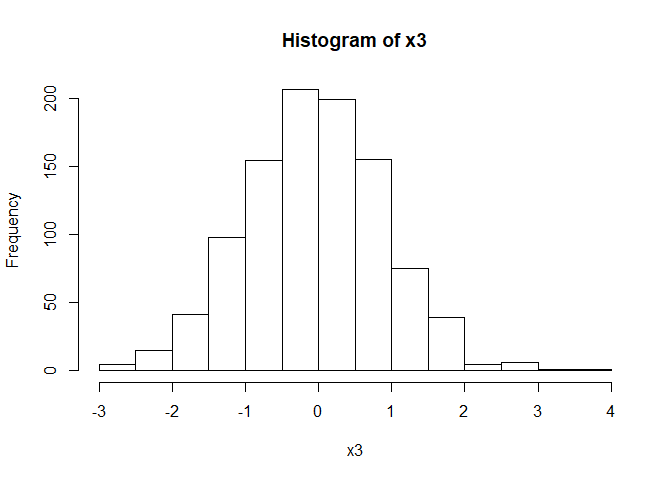

```r
x3 <- rnorm(1000)
hist(x3)
```

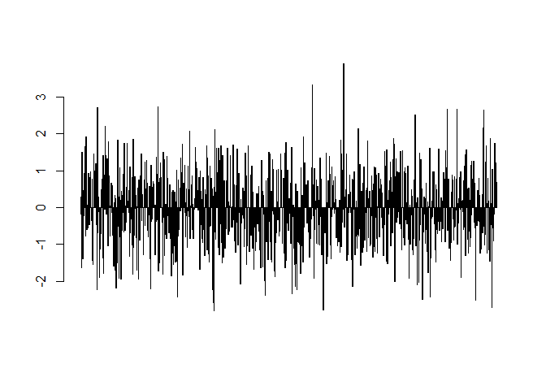

```r
barplot(x3)
```

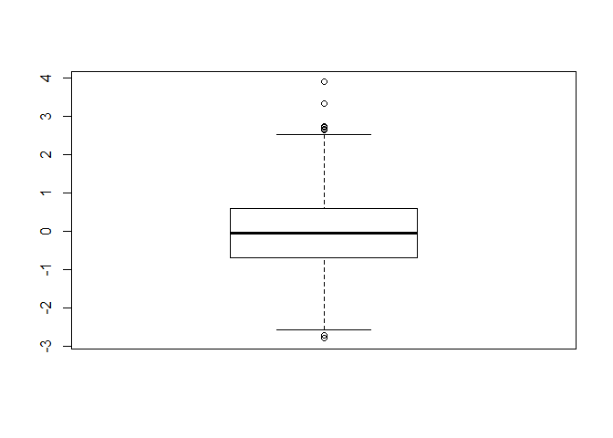

```r
boxplot(x3)
```

```r
mean(x3)
```

```
## [1] -0.0452342
```

```r
median(x3)
```

```
## [1] -0.04716315
```

```r
sd(x3)
```

```
## [1] 0.9531006
```

```r
var(x3)
```

```
## [1] 0.9084007
```

```r
quantile(x3, 0.3)
```

```
##        30%
## -0.5411215
```

```r
quantile(x3, 0.7)
```

```
##       70%
## 0.4596874
```

```r
range(x3)
```

```
## [1] -2.789136  3.900867
```

```r
sum(x3)
```

```
## [1] -45.2342
```

```r
min(x3)
```

```
## [1] -2.789136
```

```r
max(x3)
```

```
## [1] 3.900867
```

```r
ls()
```

```
##  [1] "a"           "age"         "b"           "BMW_STOCK"   "c"
##  [6] "car90"       "cells"       "cnames"      "con"         "diabetes"
## [11] "dim1"        "dim2"        "dim3"        "e"           "f"
## [16] "g"           "grades"      "h"           "infert"      "j"
## [21] "k"           "mydataframe" "mylist"      "mymatrix"    "patientdata"
## [26] "patientID"   "result"      "rnames"      "status"      "x"
## [31] "x1"          "x2"          "x3"          "y"           "z"
```

```r
rm(list=ls())
ls()
```

```
## character(0)
```

# 4 References

- Kabacoff, R. I. . (2011). “*R in Action*”. Manning Publications Co.
- Baeza, S. . (2015). “*R For Beginners*”. CreateSpace Independent Publishing Platform.
- Adler, J. (2010). “*R in a nutshell: A desktop quick reference*”. O’Reilly Media, Inc.“.
- [“*R Data Import/Export*”](https://cran.r-project.org/doc/manuals/r-release/R-data.pdf)